# Midterm 1 W26

Arden Moser

2026-01-29

## Instructions

Answer the following questions and complete the exercises in RMarkdown. Please embed all of your code and push your final work to your repository. Your code must be organized, clean, and run free from errors. Remember, you must remove the `#` for any included code chunks to run. Be sure to add your name to the author header above.

Your code must knit in order to be considered. If you are stuck and cannot answer a question, then comment out your code and knit the document. You may use your notes, labs, and homework to help you complete this exam. Do not use any other resources- including AI assistance or other students’ work.

Don’t forget to answer any questions that are asked in the prompt! Each question must be coded; it cannot be answered by a sort in a spreadsheet or a written response only.

For all plots you create, a title and clearly labeled axes must be provided. We also expect pipes `%>%` to be used wherever possible.

Be sure to push your completed midterm to your repository and upload the document to Gradescope. This exam is worth 50 points.

Please load the following libraries.

```r
library(tidyverse)
library(janitor)
```

## Part 1: Repository

**Question 1. (3 points) Before you start analyzing data, please put a link to your GitHub repository below. Your repository should have a clear README and be well-organized. Add `jmledford3115` and `bryshalm` as collaborators to your repository if you haven’t already done so.**

Link to repository: [My Repository](https://github.com/ammoser-gif/BIS15L_W26_amoser.git)

## Part 2: Data and Analysis

In the midterm 1 folder there is a second folder called `data`. Inside the `data` folder, there is a .csv file called `anolis_dat.csv`. These data came from [D. Luke Mahler, Liam J. Revell, Richard E. Glor, Jonathan B. Losos, ECOLOGICAL OPPORTUNITY AND THE RATE OF MORPHOLOGICAL EVOLUTION IN THE DIVERSIFICATION OF GREATER ANTILLEAN ANOLES, Evolution, Volume 64, Issue 9, 1 September 2010, Pages 2731–2745](https://academic.oup.com/evolut/article/64/9/2731/6854302?login=true). The original research article is included in the data folder.

*Anolis* is a genus of lizards commonly known as anoles. Anoles are found throughout the Americas, but are especially diverse in the Caribbean. The data include morphological measurements for *Anolis* lizards from the islands of the Greater Antilles. These data can be used to study patterns of morphological evolution and adaptation in *Anolis* lizards.

The variables include:  
- `species`: Species name of the anole lizard.  
- `habitat`: Habitat type where the lizard was found.  
- `hindlimb_length_mm`: Length of the lizard’s hindlimbs (in millimeters).  
- `tail_length_mm`: Length of the lizard’s tail (in millimeters).  
- `body_length_mm`: Length of the lizard’s body (in millimeters).  
- `toepad_lamellae_count`: Count of lamellae on the lizard’s toepads.  
- `island`: Island where the lizard was found.

**Question 2. (2 points) Load the data and store it as an object called `anolis`.**

```r
anolis <- read_csv("data/anolis_dat.csv")
```

**Question 3. (2 points) Use a summary function of your choice to get an idea of the structure of the data.**

```r
glimpse(anolis)
```

```
## Rows: 52
## Columns: 7
## $ Species                   <chr> "A. ahli", "A. alayoni", "A. alfaroi", "A. a…
## $ Habitat                   <chr> "Trunk-ground", "Twig", "Grass-bush", "Trunk…
## $ `Hindlimb length (mm)`    <dbl> 50.46, 25.50, 26.17, 36.80, 50.39, 49.37, 29…
## $ `Tail length (mm)`        <dbl> 81.99, 54.75, 79.00, 84.88, 154.45, 91.01, 1…
## $ `Body length (mm)`        <dbl> 51.67, 41.32, 30.95, 51.53, 72.32, 51.72, 32…
## $ `Toepad lamellae (count)` <dbl> 27, 31, 24, 36, 41, 28, 29, 28, 28, 31, 32, …
## $ Island                    <chr> "Cuba", "Cuba", "Cuba", "Hispaniola", "Cuba"…
```

**Question 4. (2 points) Clean the variable names so they are all lowercase and without special characters or spaces. Be sure to use the cleaned data for all subsequent analyses.**

```r
anolis_cleaned <- anolis %>% clean_names()
anolis_cleaned
```

```
## # A tibble: 52 × 7
##    species        habitat      hindlimb_length_mm tail_length_mm body_length_mm
##    <chr>          <chr>                     <dbl>          <dbl>          <dbl>
##  1 A. ahli        Trunk-ground               50.5           82.0           51.7
##  2 A. alayoni     Twig                       25.5           54.8           41.3
##  3 A. alfaroi     Grass-bush                 26.2           79             31.0
##  4 A. aliniger    Trunk-crown                36.8           84.9           51.5
##  5 A. allisoni    Trunk-crown                50.4          154.            72.3
##  6 A. allogus     Trunk-ground               49.4           91.0           51.7
##  7 A. alumina     Grass-bush                 30.0          106.            32.9
##  8 A. alutaceus   Grass-bush                 27.4           94.6           31.8
##  9 A. angusticeps Twig                       24.4           65.1           40.2
## 10 A. armouri     Trunk-ground               51.8          101.            56.1
## # ℹ 42 more rows
## # ℹ 2 more variables: toepad_lamellae_count <dbl>, island <chr>
```

**Question 5. (4 points) Convert the `habitat` and `island` variables to factors.**

```r
anolis_cleaned_factored <- anolis_cleaned %>%
  mutate(across(c(habitat, island), as.factor))
anolis_cleaned_factored
```

```
## # A tibble: 52 × 7
##    species        habitat      hindlimb_length_mm tail_length_mm body_length_mm
##    <chr>          <fct>                     <dbl>          <dbl>          <dbl>
##  1 A. ahli        Trunk-ground               50.5           82.0           51.7
##  2 A. alayoni     Twig                       25.5           54.8           41.3
##  3 A. alfaroi     Grass-bush                 26.2           79             31.0
##  4 A. aliniger    Trunk-crown                36.8           84.9           51.5
##  5 A. allisoni    Trunk-crown                50.4          154.            72.3
##  6 A. allogus     Trunk-ground               49.4           91.0           51.7
##  7 A. alumina     Grass-bush                 30.0          106.            32.9
##  8 A. alutaceus   Grass-bush                 27.4           94.6           31.8
##  9 A. angusticeps Twig                       24.4           65.1           40.2
## 10 A. armouri     Trunk-ground               51.8          101.            56.1
## # ℹ 42 more rows
## # ℹ 2 more variables: toepad_lamellae_count <dbl>, island <fct>
```

**Question 6. (2 points) Anole species were sampled from multiple islands. Which islands are represented in the data? Display the island names.**

```r
anolis_cleaned %>%
  distinct(island)
```

```
## # A tibble: 4 × 1
##   island
##   <chr>
## 1 Cuba
## 2 Hispaniola
## 3 Puerto Rico
## 4 Jamacia
```

**Cuba, Hispaniola, Puerto Rico, and Jamacia** are islands represented in the data.  
**Question 7. (4 points) Is sampling equal across islands? Create a plot to visualize the number of anole species sampled from each island. Be sure to label your axes and add a title.**

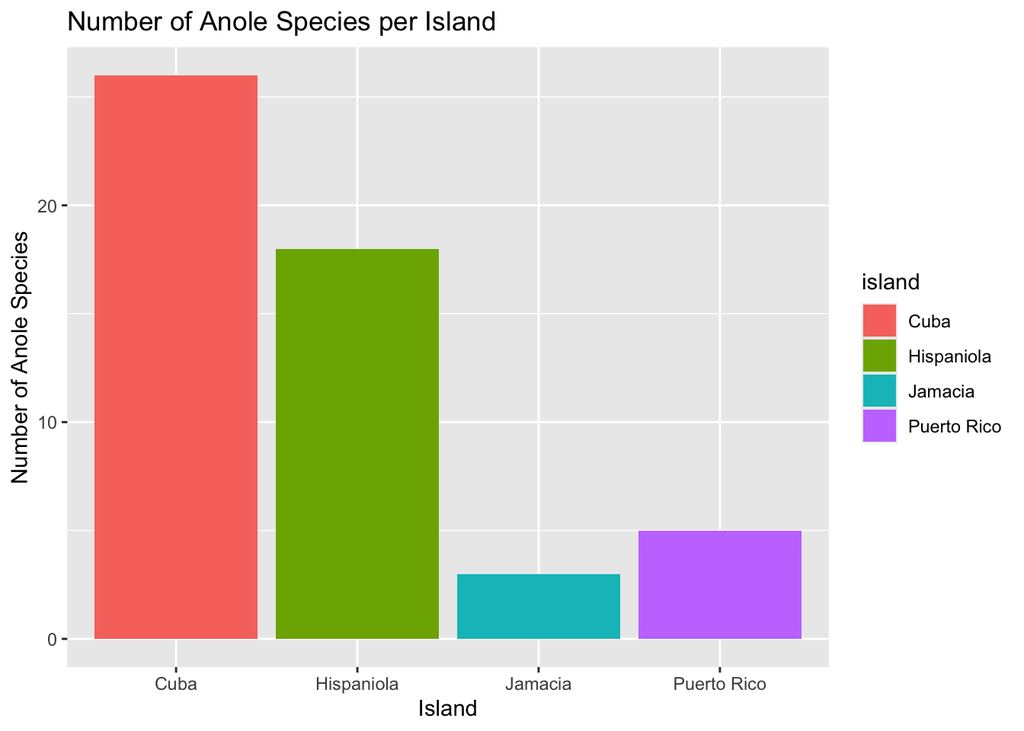

```r
anolis_cleaned %>%
  ggplot(aes(x = island, fill = island)) +
  geom_bar() +
  labs(
    title = "Number of Anole Species per Island",
    x = "Island",
    y = "Number of Anole Species"
  )
```

Sampling is not equal across the islands because Cuba has significantly more anole species recorded than the rest of the islands. For instance, Cuba expresses more than 20 species compared to Jamacia’s count of under 5 species.

**Question 8. (2 points) Which habitat types are represented in the data? Display the names of the habitat types.**

```r
anolis_cleaned %>%
  distinct(habitat)
```

```
## # A tibble: 4 × 1
##   habitat
##   <chr>
## 1 Trunk-ground
## 2 Twig
## 3 Grass-bush
## 4 Trunk-crown
```

**Trunk-ground, twig, grass-bush, and trunk-crown** are habitat types represented in the data.

**Question 9. (4 points) Is sampling equal across habitat types? Create a plot to visualize the number of anole species sampled from each habitat type. Be sure to label your axes and add a title.**

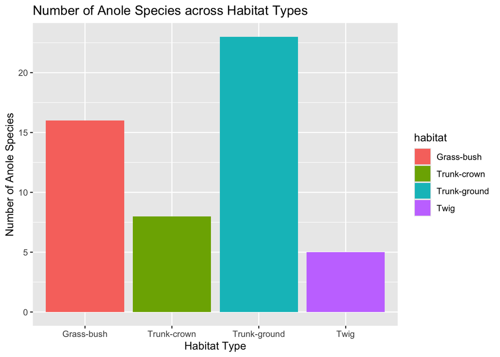

```r
anolis_cleaned %>%
  ggplot(aes(x = habitat, fill = habitat)) +
  geom_bar() +
  labs(
    title = "Number of Anole Species across Habitat Types",
    x = "Habitat Type",
    y = "Number of Anole Species"
  )
```

Sampling is not equal across habitat types because Twig has significantly less anole species recorded than the rest of the habitats. For instance, Twig expresses a mere 5 species compared to Trunk-ground’s count of over 20 species.

**Question 10. (4 points) The morphology of anoles varies based on their habitat. How does the range of hindlimb length compare among different habitats? Create a plot to visualize the distribution of hindlimb lengths across habitat types. Be sure to label your axes and add a title.**

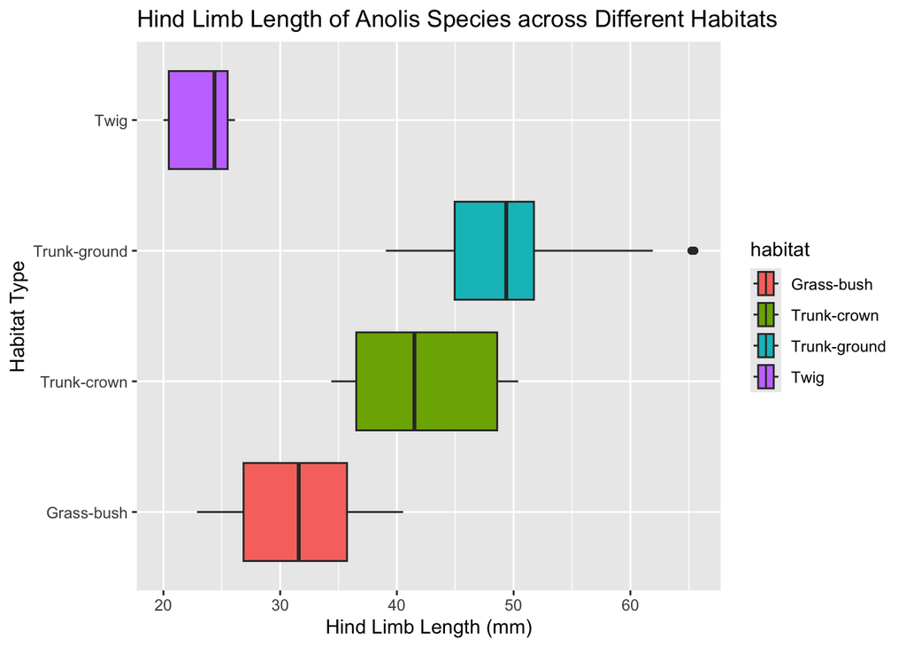

```r
anolis_cleaned %>%
  ggplot(aes(x = hindlimb_length_mm, y = habitat, fill = habitat)) +
  geom_boxplot() +
  labs(
    title = "Hind Limb Length of Anolis Species across Different Habitats",
    x = "Hind Limb Length (mm)",
    y = "Habitat Type"
  )
```

**Question 11. (4 points) The plot above is compelling, but don’t we expect larger lizards to have longer limbs? What about tail length? Shouldn’t longer lizards have longer tails? To correct for this, make two new columns: 1. `ratio_of_hindlimb_to_body`, and 2. `ratio_of_tail_to_body`. Don’t forget to add these columns to the anolis data frame.**

```r
anolis_cleaned %>%
  mutate(ratio_of_hindlimb_to_body = hindlimb_length_mm / body_length_mm) %>%
  mutate(ratio_of_tail_to_body = tail_length_mm / body_length_mm)
```

```
## # A tibble: 52 × 9
##    species        habitat      hindlimb_length_mm tail_length_mm body_length_mm
##    <chr>          <chr>                     <dbl>          <dbl>          <dbl>
##  1 A. ahli        Trunk-ground               50.5           82.0           51.7
##  2 A. alayoni     Twig                       25.5           54.8           41.3
##  3 A. alfaroi     Grass-bush                 26.2           79             31.0
##  4 A. aliniger    Trunk-crown                36.8           84.9           51.5
##  5 A. allisoni    Trunk-crown                50.4          154.            72.3
##  6 A. allogus     Trunk-ground               49.4           91.0           51.7
##  7 A. alumina     Grass-bush                 30.0          106.            32.9
##  8 A. alutaceus   Grass-bush                 27.4           94.6           31.8
##  9 A. angusticeps Twig                       24.4           65.1           40.2
## 10 A. armouri     Trunk-ground               51.8          101.            56.1
## # ℹ 42 more rows
## # ℹ 4 more variables: toepad_lamellae_count <dbl>, island <chr>,
## #   ratio_of_hindlimb_to_body <dbl>, ratio_of_tail_to_body <dbl>
```

**Question 12. (4 points) Create a new plot that examines the distribution of `ratio_of_hindlimb_to_body` across habitat types. How does this plot differ from the one you made in Problem 10? Be sure to label your axes and add a title.**

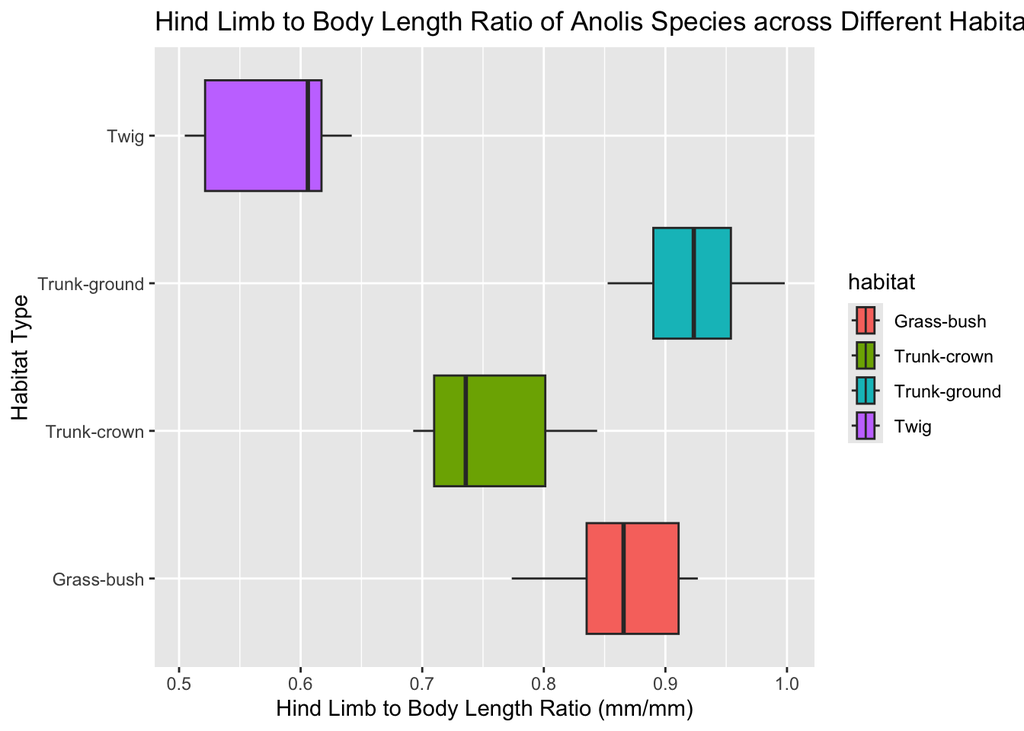

```r
anolis_cleaned %>%
  mutate(ratio_of_hindlimb_to_body = hindlimb_length_mm / body_length_mm) %>%
  ggplot(aes(x = ratio_of_hindlimb_to_body, y = habitat, fill = habitat)) +
  geom_boxplot() +
  labs(
    title = "Hind Limb to Body Length Ratio of Anolis Species across Different Habitats",
    x = "Hind Limb to Body Length Ratio (mm/mm)",
    y = "Habitat Type"
  )
```

**Problem 13. (4 points) A longer tail provides better balance and agility. Create a plot that examines the relationship between body length and tail length. Color the points by habitat type and add a line of best fit. What does this plot suggest about the relationship between body length and tail length? What do you notice about lizards in the `Grass-bush` habitat? Be sure to label your axes and add a title.**

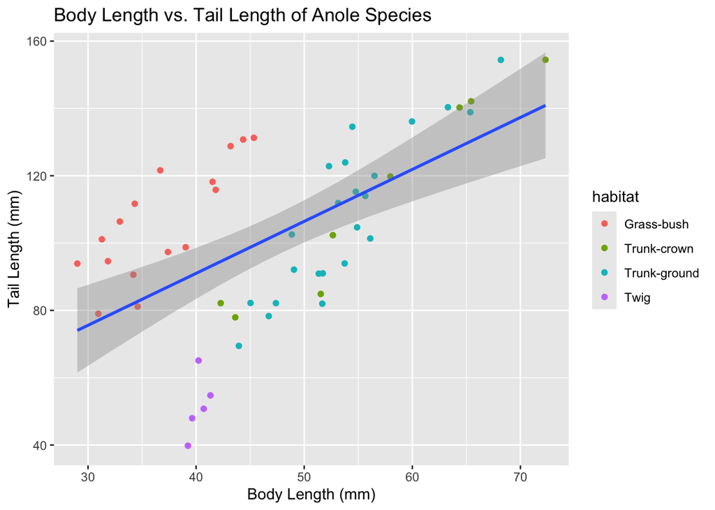

```r
anolis_cleaned %>%
  ggplot(aes(x = body_length_mm, y = tail_length_mm)) +
  geom_point(aes(color = habitat)) +
  geom_smooth(method = "lm") +
  labs(
    title = "Body Length vs. Tail Length of Anole Species",
    x = "Body Length (mm)",
    y = "Tail Length (mm)"
  )
```

Becuase the plot presents a positive, linear line of best fit, it suggests that body length generally correlates to a longer tail. However, lizards in the ‘Grass-bush’ habitat have unusually long tails for their short bodies.

**Problem 14. (4 points) Toepad lamellae are transverse, plate-like structures found on the ventral surface of the digits. They are a key adaptation that allows anoles to cling to and move efficiently on smooth and vertical surfaces. What is the mean number of toepad lamellae for each habitat type?**

```r
anolis_cleaned %>%
  select(toepad_lamellae_count, habitat) %>%
  group_by(habitat) %>%
  summarize(mean_toepad_lamellae_count = mean(toepad_lamellae_count))
```

```
## # A tibble: 4 × 2
##   habitat      mean_toepad_lamellae_count
##   <chr>                             <dbl>
## 1 Grass-bush                         28.3
## 2 Trunk-crown                        38.5
## 3 Trunk-ground                       30.0
## 4 Twig                               27.6
```

The mean number of toepad lamellae for each habitat types is about **28 for ‘Grass-bush’**, **39 for ‘Trunk-crown’**, **30 for ‘Trunk-ground’**, and **28 for ‘Twig’**.

**Problem 15. (5 points) The number of toepad lamellae is significantly different for trunk-crown species. But, is this consistent across all islands? Make a plot that shows the range in number of toepad lamellae by island for trunk-crown species only. Be sure to label your axes and add a title.**

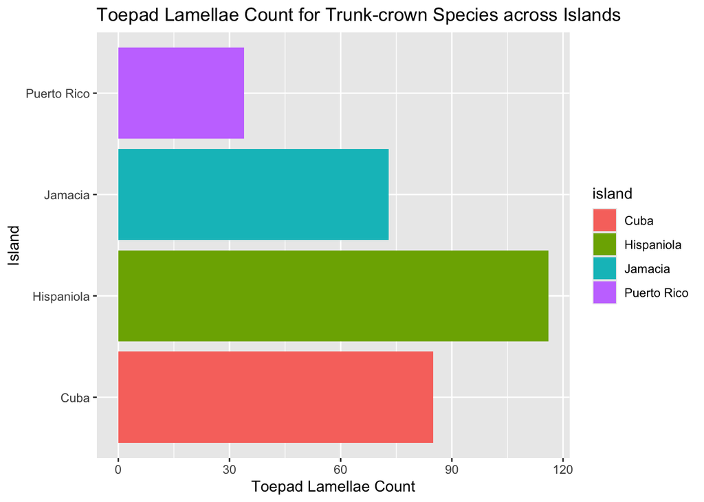

```r
anolis_cleaned %>%
  select(toepad_lamellae_count, habitat, island) %>%
  filter(habitat == "Trunk-crown") %>%
  ggplot(aes(x = toepad_lamellae_count, y = island, fill = island)) +
  geom_col() +
  labs(
    title = "Toepad Lamellae Count for Trunk-crown Species across Islands",
    x = "Toepad Lamellae Count",
    y = "Island"
  )
```

## Submit the Midterm

1. Save your work and knit the .rmd file.
2. Open the .html file and “print” it to a .pdf file in Google Chrome (not Safari).
3. Go to the class Canvas page and open Gradescope.
4. Submit your .pdf file to the midterm assignment- be sure to assign the pages to the correct questions.
5. Commit and push your work to your repository.